# Relatório 02 - Estatística Descritiva

Alex Gama

12/09/2024

# 1 Objetivo

Utilizar métodos e técnicas estatísticas que possibilitem sumarizar, calcular e analisar informações com vistas à tomada de decisões.

## 1.1 Estatística Descritiva

As estatísticas descritivas são números que resumem e descrevem o conjuntos de dados. As estatísticas descritivas apenas “descrevem” os dados, elas não representam generalizações da amostra para a população.

## 1.2 Conceitos básicos

### 1.2.1 População

É todo conjunto, finito ou infinito, que possui ao menos uma característica em comum entre todos os seus elementos componentes.

População Finita: é aquela população em que é possível enumerar todos os seus elementos componentes.

População Infinita: é aquela população em que não é possível enumerar todos os seus elementos componentes.

### 1.2.2 Censo

É o conjunto dos dados estatísticos dos habitantes de uma cidade, estado, etc, com todas as suas características, num determinado período de tempo. É a coleta exaustiva das informações de todas as “N” unidades da população.

### 1.2.3 Amostra

É um subconjunto, uma parte selecionada da totalidade de observações abrangidas pela população da qual se quer inferir alguma coisa. (parte representativa da população)

### 1.2.4 Amostragem

É o processo de coleta das informações de parte da população - “n” - chamada amostra, mediante métodos adequados de seleção destas unidades.

# 2 Coleta, organização e apresentação dos dados

A coleta de dados é o processo de reunir informações ou dados brutos a partir de diversas fontes para análise posterior. Essa etapa é crucial, pois a qualidade da análise estatística depende diretamente da qualidade dos dados coletados.

A organização dos dados refere-se ao processo de estruturar e classificar os dados brutos de maneira sistemática para facilitar a análise e interpretação. Isso envolve a criação de tabelas, agrupamento de dados em categorias, e a preparação para análises estatísticas.

A apresentação dos dados é o processo de exibir os dados organizados de maneira clara e compreensível, geralmente utilizando gráficos, tabelas e diagramas. O objetivo é comunicar os resultados de forma eficaz para facilitar a interpretação e a tomada de decisões.

# 3 Medidas de Posição

A tendência central da distribuição de freqüências de uma variável em um conjunto de dados é caracterizada pelo valor típico dessa variável. Essa é uma maneira de resumir a informação contida nos dados, pois escolheremos um valor para representar todos os outros. Assim, poderíamos perguntar, por exemplo, qual é a altura típica dos brasileiros adultos no final da década de 90 e compará-la com o valor típico da altura dos brasileiros no final da década de 80, a fim de verificar se os brasileiros estão se tornando, em geral, mais altos, mais baixos ou não sofreram nenhuma alteração em sua altura típica. Fazer essa comparação utilizando medidas-resumo (as alturas típicas em cada período) é bem mais sensato do que comparar os dois conjuntos de dados valor a valor, o que seria inviável. Mas, como identificar o valor típico de um conjunto de dados? Existem três medidas que podem ser utilizadas para descrever a tendência central de um conjunto de dados: a média, a mediana e a moda. Apresentaremos essas três medidas e discutiremos suas vantagens e desvantagens.

## 3.1 . Média Aritmética Simples

A média aritmética simples (que chamaremos apenas de média) é a medida de tendência central mais conhecida e usada para o resumo de dados. Essa popularidade pode ser devida à facilidade de cálculo e à idéia simples que ela nos sugere. De fato, se queremos um valor que represente a altura dos brasileiros adultos, por que não medir as alturas de uma amostra de brasileiros adultos, somar os valores e dividir esse “bolo” igualmente entre os participantes? Essa é a idéia da média aritmética. Para apresentar a média, primeiramente vamos definir alguma notação. A princípio, essa notação pode parecer desnecessária, mas facilitará bastante nosso trabalho futuro.

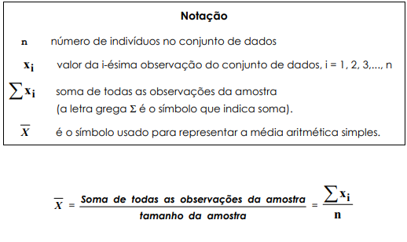

## 3.2 Mediana

A mediana de um conjunto de dados é definida como sendo o “valor do meio” desse conjunto de dados, dispostos em ordem crescente, deixando metade dos valores acima dela e metade dos valores abaixo dela. Como calcular a mediana? Basta seguir sua definição. Vejamos:

• **n é ímpar:** Existe apenas um “valor do meio”, que é a mediana

Seja o conjunto de dados ( 2 ; 3,3 ; 2,5 ; 5,6 ; 5 ; 4,3 ; 3,2 ). Ordenando os valores (2 ; 2,5 ; 3,2 ; 3,3 ; 4,3 ; 5 ; 5,6). O valor do meio é o 3,3 . A mediana é o valor 3,3.

• **n é par:** Existem dois “valores do meio”. A mediana é média aritmética simples deles. Seja o conjunto de dados ( 3 ; 4,5 ; 5,5 ; 2,5 ; 1,3 ; 6 ). Ordenando os valores (1,3 ; 2,5 ; 3 ; 4,5 ; 5,5 ; 6) Os valores do meio são 3 e 4,5. A mediana é (3 + 4,5)/2 = 3,75. Como medida de tendência central, a mediana é até mais intuitiva do que a média, pois representa, de fato, o centro (meio) do conjunto de valores ordenados. Assim como a média, o valor da mediana não precisa coincidir com algum dos valores do conjunto de dados. Em particular, quando os dados forem de natureza contínua, essa coincidência dificilmente ocorrerá.

## 3.3 Moda

Uma maneira alternativa de representar o que é “típico” é através do valor mais freqüente da variável, chamado de moda.

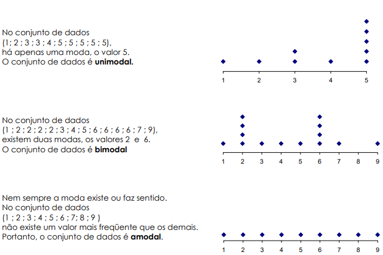

No caso de uma tabela de freqüências, a classe de maior freqüência é chamada classe modal. A moda é também a única das medidas de tendência central que faz sentido no caso de variáveis qualitativas. Assim, a categoria dessas variáveis que aparecer com maior freqüência é chamada de categoria modal.

# 4 Medidas de dispersão

As Medidas de dispersão (ou variabilidade) são medidas que indicam a variação dos dados de um conjunto

Podemos dividi-las em dois grupos:

**Medidas de dispersão absoluta:**

- amplitude total;
- amplitude interquartílica;
- desvio médio;
- variância;
- desvio-padrão.

Vejamos sobre as propriedades da dispersão absoluta.

1ª Propriedade: A soma ou a subtração de uma constante não altera as medidas de dispersão absoluta.

2ª Propriedade: A multiplicação ou a divisão de uma constante altera as medidas de dispersão absoluta.

**Medidas de dispersão relativa:**

coeficiente de variação (de Pearson); e variância relativa. Também conheçamos as propriedades da dispersão relativa

1ª Propriedade: A soma ou a subtração de uma constante altera as medidas de dispersão relativa.

2ª Propriedade: A multiplicação ou a divisão de uma constante não altera as medidas de dispersão relativa.

## 4.1 Amplitude total

Sabemos que a amplitude é a diferença entre o valor máximo e mínimo, bem tranquilo.

Apenas destacamos que a amplitude para dados agrupados em classes é encontrada a partir da diferença entre o ponto médio da última classe e da primeira.

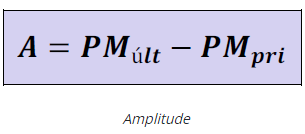

## 4.2 Desvio médio

O desvio médio é uma medida estatística que representa a média das diferenças entre cada valor de um conjunto de dados e a média aritmética desses dados. Em outras palavras, o desvio médio indica o quanto, em média, os dados se afastam da média.

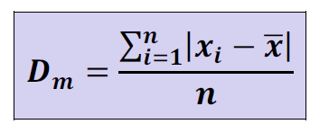

Vejamos um exemplo númerio para facilitar o entendimento.

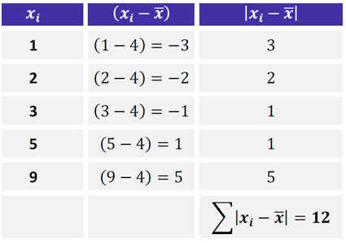

**Importante observar que buscamos o somatório do módulo dessa diferença.**

Dm = 12/5 = 2,4

## 4.3 Variância

A variância basicamente mostra o quão dispersos os dados estão em relação à média. Trata-se da média dos quadrados dos desvios em relação à média.

Vejamos a fórmula da variância populacional (parâmetro populacional) e variância amostral (estimador), respectivamente.

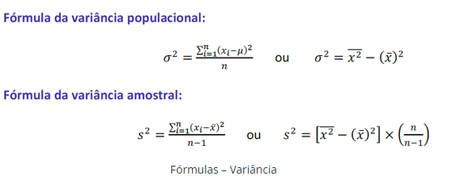

Assim, podemos pensar também que a variância é a diferença entre a média dos quadrados e o quadrado das médias.

Também destacamos a seguinte Propriedade da Variância.

Propriedade: A multiplicação ou a divisão de todos os valores de uma variável por uma constante k é afeta pelo valor quadrado dessa constante.

## 4.4 Desvio padrão

Basicamente ele pode ser determinado pela raiz quadrada da variância.

Assim os valores próximos da média darão um desvio padrão pequeno e por ser uma raiz quadrada, o valor sempre será igual ou maior que zero.

Atente-se a diferença entre a propriedade da multiplicação ou divisão de uma constante para o desvio padrão e variância.

Propriedade: A multiplicação ou a divisão de todos os valores de uma variável por uma constante k é afeta pelo valor dessa constante.